# Proyecto final

Patricia Quintana

18/11/2019

# 1. Expresiones regulares

> En cómputo teórico y teoría de lenguajes formales una expresión regular, o expresión racional, es una secuencia de caracteres que conforma un patrón de búsqueda. También son conocidas como *regex* o *regexp*, por su contracción de las palabras inglesas *regular expression*. Son principalmente utilizadas para la búsqueda de patrones de cadenas de caracteres u operaciones de sustituciones.

según [Wikipedia](https://es.wikipedia.org/wiki/Expresi%C3%B3n_regular)

En este apartado se van a comparar dos páginas webs sobre expresiones regulares:

- [*R-tools*](https://www.r-studio.com/es/Unformat_Help/regularexpressions.html)
- [*RPubs*](http://rpubs.com/ydmarinb/429756)

## 1.1 Similitudes

1. Las páginas webs han sido fáciles de encontrar porque han sido de los primeros enlaces que me han salido en la búsqueda en Google.
2. En ambos links aparece la definición del término expresión regular.
3. La visualización de las webs están definidas estructuralmente.
4. Algunos de los tipos de expresiones regulares aparecen en ambas páginas, como por ejemplo:
   - `.`
   - `*`
   - `^`
   - `$`
   - `[...]`
   - `[^...]`
   - `\x`

## 1.2 Diferencias

1. La página de *R-tools* contiene información escueta y general, en cambio *RPubs* tiene una información específica y divide las expresiones según su tipología.
2. En cuanto a la estética de las webs, como se ha comentado antes, en ambas páginas se ve muy fácilmente la estructura pero *R-tools* está menos elaborada que *Rpubs*. Además, la segunda web contiene más información sobre las expresiones regulares.
3. Otra clara diferencia es que la web de *Rpubs* tiene más información y está mejor explicada, un ejemplo es que hay un apartado que enseña como implementarlo en *RStudio*.

## 1.3 Conclusión

En mi opinión, la página de *RPubs* es mejor ya que contiene más información y de forma más ordenada con los diferentes tipos de expresiones regulares. En cambio, la web *R-tools* tiene información muy genérica y visualmente es menos atractiva.

# 2. Recursos sobre markdown

> **Markdown** es un lenguaje creado por John Gruber que facilita y simplifica la escritura y lectura de las publicaciones en HTML. En esta sección he decidio coger dos webs y analizarlas por separado:
- https://es.r4ds.hadley.nz/r-markdown.html
- https://commonmark.org/help/tutorial/index.html

## 2.1 Primera página

La primera página web es un [libro](https://es.r4ds.hadley.nz/r-markdown.html) que contiene información sobre Rstudio. En el tema 27 trata sobre RMarkdown y sus posibles usos:

- Introducción
- Rmarkdown básico: explica como usarlo
- Formatear el texto: como poner texto en negrita, cursiva o enumerar
- Bloques de códigos
- Encabezados YALM
- Enunciados de ejercicios para practicar

## 2.2 Segunda página

La segunda página se trata de un [tutorial](https://commonmark.org/help/tutorial/index.html) de RMarkdown, explica de forma breve algunos de los posibles recursos y más tarde se convierte en un tutorial interactivo para que el usuario practique, además ofrece *hints* por si tienes problemas a la hora de resolver los ejercicios.

## 2.3 Conclusión

Las páginas web explicadas son muy diferentes ya que la primera contiene mucha más información que la segunda y hace un análisis más profundo sobre RMarkdown, en cambio, la segunda página contiene menos información, pero al ser un tutorial interactivo puedes prácticar y te corrige las respuestas, a diferencia que la primera, que sólo aparecen los enunciados de los ejercicios.

# 3. Estudio del data frame *ChickenWeight*

En este apartado vamos a analizar los datos de *ChickWeight*, un experimento que observa el efecto de la dieta en el crecimiento temprano de los pollos.

## 3.1 Resumen de la base de datos

|  | weight | Time | Chick | Diet |
| --- | --- | --- | --- | --- |
|  | Min. : 35.0 | Min. : 0.00 | 13 : 12 | 1:220 |
|  | 1st Qu.: 63.0 | 1st Qu.: 4.00 | 9 : 12 | 2:120 |
|  | Median :103.0 | Median :10.00 | 20 : 12 | 3:120 |
|  | Mean :121.8 | Mean :10.72 | 10 : 12 | 4:118 |
|  | 3rd Qu.:163.8 | 3rd Qu.:16.00 | 17 : 12 | NA |
|  | Max. :373.0 | Max. :21.00 | 19 : 12 | NA |
|  | NA | NA | (Other):506 | NA |

El *dataset* consta de 578 filas y 4 columnas. En este apartado se hará un resumen sobre las variables y un estudio de los datos con gráficas y una tabla.

### 3.1.1 Las variables.

1. Weight

La variable *weight* es un vector numérico que representa el peso de los pollos en gramos.

2. Time

La variable *time* es un vector númerico que indica el número de días desde que el pollo nació cuando la medición del peso fue hecha.

3. Chick

La variable *chick* un factor ordenado con niveles 18 <… <48 que proporciona un identificador único para el pollo. La ordenación de los niveles agrupa a los pollitos en la misma dieta y los ordena de acuerdo con su peso final (más liviano a más pesado) dentro de la dieta.

4. Diet

La variable *diet* es un factor que va desde el nivel 1 hasta el 4 e indica que dieta ha recibido el pollo.

- **Detalles de las variables:**  
  Los pesos corporales de los pollos se midieron al nacer y cada dos días a partir de entonces hasta el día 20. También se midieron el día 21. Hubo cuatro grupos de pollitos con diferentes dietas proteicas.

### 3.1.2 Gráficos

En este apartado, se va a estudiar mediante gráficos el cambio del peso según la dieta para ellos hemos representado un gráfico de caja y un diagrama de puntos dividido en facetas.

#### **Gráfico de puntos que estudia la evolución del peso durante el tiempo según el tipo de dieta.**

A continuación, se representa el *gráfico 1* que está dividido en facetas, cada una representa la dieta que ha recibido el pollo. Como se puede observar, la gráfica que corresponde a la *dieta 3* es la que alcanza los niveles de peso más altos. En cuanto a la tendecia, se puede observar que en la *dieta 1* y la *dieta 2* el crecimiento es más constante, en cambio en la *dieta 3* y la *dieta 4* hay cambios pequeños durante el tiempo. El eje x representa el tiempo que tiene el pollo y se ve perfectamente reflejado que cuanto más tiempo de vida tenga el pollo, más peso tendrá.

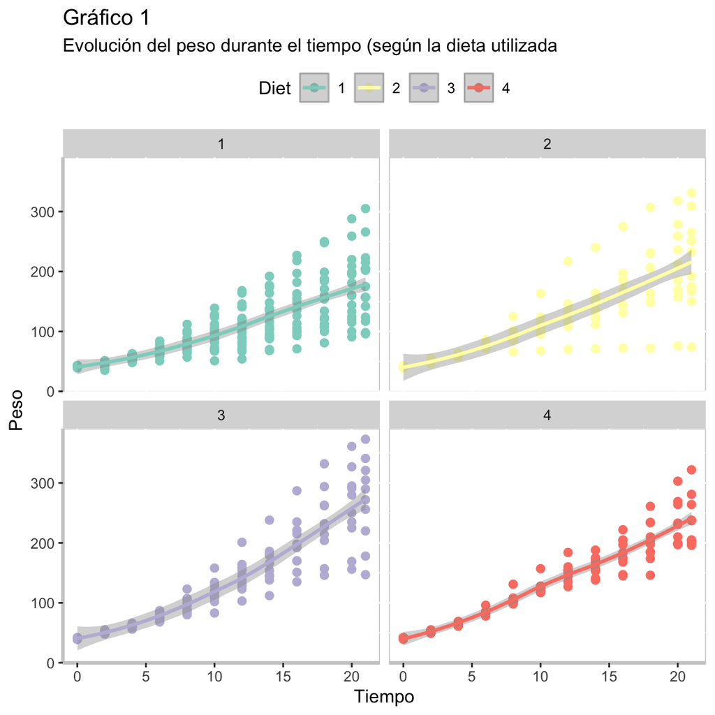

#### **Gráfico de caja que analiza la evolución del peso según la dieta establecida.**

Abajo se representa un gráfico de caja en el que se comparan dos variables (*peso* y *dieta*); mostrando las distribuciones que corresponden a la variable *peso* y cada serie corresponde a una categoría de la varibale *dieta*. Puede observarse que la *dieta 3* tiene una distribucion mayor, es decir que tiene mayor dispersión y presenta un peso promedio (mediana) igual que la *dieta 4*. Además, se puede observar que en las *dietas 1* y *2* hay *outliers* representados por una estrella, es decir, datos atípicos que están muy alejados de otros datos. Si comparamos las cajas de las dietas se puede observar que la *dieta 3* es la más eficiente a la hora de engordar a los animales, y la *dieta 1* la que menos.

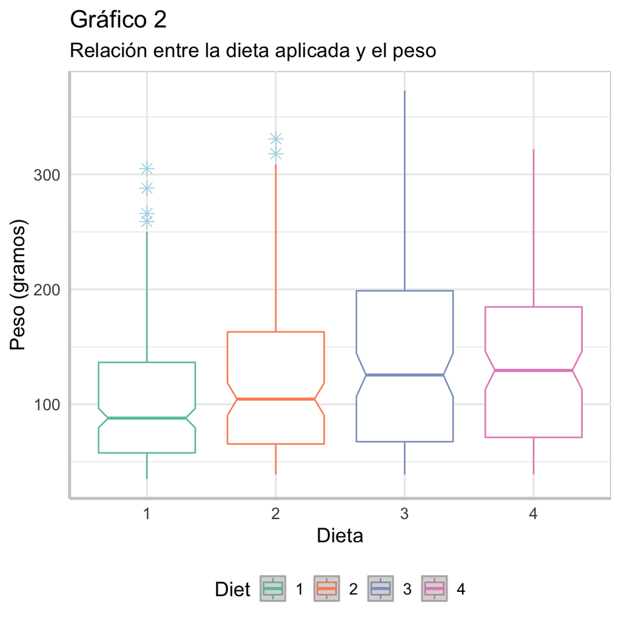

### 3.1.3 Tabla

Tabla 1: Representación de `ChickWeight1` con `formattable()`

| Peso | Tiempo | Pollos | Dieta |
| --- | --- | --- | --- |
| 327 | 20 | 34 | 3 |
| 331 | 21 | 21 | 2 |
| 332 | 18 | 35 | 3 |
| 341 | 21 | 34 | 3 |
| 361 | 20 | 35 | 3 |
| 373 | 21 | 35 | 3 |

Por último, la *Tabla 1* muestra los datos *ChickenWeight1*, este *data frame* ordena los datos de *ChickenWeight* según el peso. En la tabla se ha recogido los sujetos con más peso, como se puede observar la dieta más efectiva para engordar a los pollos es *Diet 3*, también podemos deducir por la tabla que las variables *time* y *weight* están relacionadas positivamente ya que a más edad, los pollos pesan más.